# Reducing re-arrests in Chicago

# Introduction

In January 2012, the Cook County State’s Attorney’s Office (CCSAO) established a program intended to reduce re-arrest among people on bail awaiting trial. The program ran through October 2013. The code in this notebook aims to evaluate the effectiveness of the program using data provided by CCSAO.

The notebook contains R code and outputs, and the code that creates it can be found at https://github.com/luizaandrade/pdri-assignment.

```r
devtools::install_github('bbc/bbplot')

packages <-
  c(
    "here",
    "tidyverse",
    "skimr",
    "lubridate",
    "assertthat",
    "sjlabelled",
    "naniar",
    "lfe",
    "vtable",
    "viridis",
    "sjlabelled",
    "bbplot",
    "huxtable"
  )

pacman::p_load(
  packages,
  character.only = TRUE
)

colors <- c(
  "#ffa700",
  "#91bfff",
  "#ff8100"
)
```

# Data cleaning

The data shared by State’s Attorney’s office contained four data tables:

- `cases.csv`
- `demo.csv`
- `prior_arrests.csv`
- `grades.csv`

The code below imports it into R; adjusts formats to make it easier to handle in R; and performs basic quality checks.

## Cases

The main data tables contains the dates of arrest and disposition (trial or court appearance) during the period in which the program operated. The file also contains an indicator of whether the arrestee was referred to the intervention program for that arrest (i.e. whether they were treated), whether the person was re-arrested while awaiting trial, the number of prior arrests at the time of program entry, and the arrest location.

We will start by loading and inspecting the data:

```r
cases <-
  read.csv(
    here(
      "data",
      "raw",
      "case.csv"
    )
  )

skim(cases)
```

**Variable type: character**

| skim_variable | n_missing | complete_rate | min | max | empty | n_unique | whitespace |
| --- | --- | --- | --- | --- | --- | --- | --- |
| arrest_date | 0 | 1 | 10 | 10 | 0 | 666 | 0 |
| dispos_date | 0 | 1 | 10 | 10 | 0 | 1486 | 0 |
| address | 0 | 1 | 19 | 51 | 0 | 25424 | 0 |

**Variable type: numeric**

| skim_variable | n_missing | complete_rate | mean | sd | p0 | p25 | p50 | p75 | p100 | hist |
| --- | --- | --- | --- | --- | --- | --- | --- | --- | --- | --- |
| caseid | 0 | 1 | 50011.31 | 28819.97 | 4 | 24879.75 | 50065 | 74970.25 | 99998 | ▇▇▇▇▇ |
| person_id | 0 | 1 | 10189.54 | 5981.88 | 1 | 4985.75 | 10194 | 15261.25 | 24981 | ▇▇▇▇▁ |
| treat | 0 | 1 | 0.53 | 0.50 | 0 | 0.00 | 1 | 1.00 | 1 | ▇▁▁▁▇ |
| re_arrest | 0 | 1 | 0.21 | 0.41 | 0 | 0.00 | 0 | 0.00 | 1 | ▇▁▁▁▂ |
| prior_arrests | 0 | 1 | 3.80 | 2.14 | 0 | 2.00 | 4 | 5.00 | 16 | ▇▆▂▁▁ |

The data table contains 26000 unique observations over 26000 rows. The unique identifier in this data table is the `caseid`, containing 26000 unique values. `person_id`, on the other hand, contains 15353 unique values and is a foreign key that can be used to link it to other data tables

To prepare the data for analysis, we will change the formats of each variable. Right now, they are all stored as either text or numbers. However, we can see that there are date in the data, and that the variables `treat` and `re_arrest` are dummies. Dummy variables are better handled by R is stored in logical format. Finally, addresses are not standardized: they vary in their usage of upper and lower cases. We will standardize them by making them all upper case.

```r
cases <-
  cases %>%
  mutate(
    # Change dates to date format
    across(
      ends_with("date"),
      ~ as_date(.)
    ),
    # Change dummies to logical format
    across(
      c(treat, re_arrest),
      ~ as.logical(.)
    ),
    # Make text all upper case
    address = str_to_upper(address)
  )
```

This data will be saved in R format for easier handling in the future.

```r
write_rds(
  cases,
  here(
    "data",
    "clean",
    "case.rds"
  )
)
```

## Demographic characteristics

The data table called `demo.csv` contains demographic information about arrestees, including some who were not included in the program evaluation.

```r
demo <-
  read.csv(
    here(
      "data",
      "raw",
      "demo.csv"
    )
  )
```

The data table contains 15715 unique observations over 20436 rows, meaning there are full duplicates in it. The unique identifier in this data table is the `person_id`, containing 15715 unique values. The first thing to do before using this data table to make sure we don’t have multiple observations for a single individual, as this could mean that these individuals will receive a higher weight in analysis.

```r
# Remove duplicate rows
demo <-
  demo %>%
  unique
```

We can now explore the data table to understand how the information is organized.

```r
skim(demo)
```

**Variable type: character**

| skim_variable | n_missing | complete_rate | min | max | empty | n_unique | whitespace |
| --- | --- | --- | --- | --- | --- | --- | --- |
| race | 0 | 1 | 5 | 5 | 0 | 3 | 0 |
| gender | 0 | 1 | 1 | 6 | 0 | 4 | 0 |
| bdate | 0 | 1 | 10 | 10 | 0 | 7603 | 0 |

**Variable type: numeric**

| skim_variable | n_missing | complete_rate | mean | sd | p0 | p25 | p50 | p75 | p100 | hist |
| --- | --- | --- | --- | --- | --- | --- | --- | --- | --- | --- |
| person_id | 0 | 1 | 10508.25 | 6178.87 | 1 | 5180.5 | 10465 | 15636.5 | 24981 | ▇▇▇▇▂ |

The only numeric variable in this data table is the ID. All other variables are stored as characters. However, we know that `bdate` is an individual’s birth date, and should therefore be in date format. Additionally, race and gender both have only a few unique values, which means they should probably be handled as categorical variables.

```r
demo <-
  demo %>%
  mutate(
    # Transform categorical variables into factors
    across(
      c(race, gender),
      ~ as_factor(.)
    ),
    # Turn birth date into a date
    bdate = as_date(bdate)
  )

# Check the data again
skim(demo)
```

**Variable type: Date**

| skim_variable | n_missing | complete_rate | min | max | median | n_unique |
| --- | --- | --- | --- | --- | --- | --- |
| bdate | 0 | 1 | 1943-05-12 | 2004-04-17 | 1983-10-02 | 7603 |

**Variable type: factor**

| skim_variable | n_missing | complete_rate | ordered | n_unique | top_counts |
| --- | --- | --- | --- | --- | --- |
| race | 0 | 1 | FALSE | 3 | BLA: 11423, WHI: 3525, ASI: 767 |
| gender | 0 | 1 | FALSE | 4 | M: 11707, F: 2936, mal: 893, fem: 179 |

**Variable type: numeric**

| skim_variable | n_missing | complete_rate | mean | sd | p0 | p25 | p50 | p75 | p100 | hist |
| --- | --- | --- | --- | --- | --- | --- | --- | --- | --- | --- |
| person_id | 0 | 1 | 10508.25 | 6178.87 | 1 | 5180.5 | 10465 | 15636.5 | 24981 | ▇▇▇▇▂ |

There are three categories in race (BLACK, WHITE, and ASIAN) and four categories in gender (M, F, Male and Female). We will standardize these categories to handle them correctly.

```r
demo <-
  demo %>%
  mutate(
    # Standardize different codes for same gender
    gender =
      gender %>%
      fct_recode(
        "male" = "M",
        "female" = "F"
      ),
    # Make all factors proper case
    across(
      c(race, gender),
      ~ str_to_title(.) %>%
        as_factor
    )
  )
```

Finally, let’s save the data for future use.

```r
demo %>%
  write_rds(
    here(
      "data",
      "clean",
      "demo.rds"
    )
  )
```

## Prior arrests

This data table reflects the arrests among individuals in `case.csv` that occurred before the program implementation, between 2008 and 2011.

```r
prior_arrests <-
  read.csv(
    here(
      "data",
      "raw",
      "prior_arrests.csv"
    )
  )
```

There are 13560 unique person IDs and 43548 unique observations, meaning there are duplicate entries. This could be because a person was arrested more than once on the same day or because the same arrest is recorded twice in the data. We know from the CCSAO that it is possible for the same individual to be arrested multiple times in the same day.

```r
skim(prior_arrests)
```

**Variable type: character**

| skim_variable | n_missing | complete_rate | min | max | empty | n_unique | whitespace |
| --- | --- | --- | --- | --- | --- | --- | --- |
| arrest_date | 0 | 1 | 10 | 10 | 0 | 1461 | 0 |

**Variable type: numeric**

| skim_variable | n_missing | complete_rate | mean | sd | p0 | p25 | p50 | p75 | p100 | hist |
| --- | --- | --- | --- | --- | --- | --- | --- | --- | --- | --- |
| person_id | 0 | 1 | 9995.72 | 5778.02 | 1 | 4964 | 10034 | 14965 | 20000 | ▇▇▇▇▇ |

The arrest date is currently stored as text, which makes it harder to process it. We will change its format and then save the data:

```r
prior_arrests <-
  prior_arrests %>%
  mutate(
    arrest_date = as_date(arrest_date)
  )
```

Finally, we will save the data in R format:

```r
prior_arrests %>%
  write_rds(
    here(
      "data",
      "clean",
      "prior_arrests.rds"
    )
  )
```

## Grades

The last data table we received includes 9th and 10th grade course grades for a subset of individuals in `case.csv`.

```r
grades <-
  read.csv(
    here(
      "data",
      "raw",
      "grades.csv"
    )
  )
```

The data table contains 11251 unique observations over 11251 r ows. It also contains data for 11251 unique individuals.

```r
skim(grades)
```

**Variable type: character**

| skim_variable | n_missing | complete_rate | min | max | empty | n_unique | whitespace |
| --- | --- | --- | --- | --- | --- | --- | --- |
| gr9_fall_math | 0 | 1 | 0 | 1 | 2251 | 5 | 0 |
| gr9_fall_sci | 0 | 1 | 0 | 1 | 2251 | 5 | 0 |
| gr9_fall_eng | 0 | 1 | 0 | 1 | 2251 | 5 | 0 |
| gr9_fall_hist | 0 | 1 | 0 | 1 | 2251 | 5 | 0 |
| gr9_spring_math | 0 | 1 | 0 | 1 | 2251 | 5 | 0 |
| gr9_spring_sci | 0 | 1 | 0 | 1 | 2251 | 5 | 0 |
| gr9_spring_eng | 0 | 1 | 0 | 1 | 2251 | 5 | 0 |
| gr9_spring_hist | 0 | 1 | 0 | 1 | 2251 | 5 | 0 |
| gr10_fall_math | 0 | 1 | 0 | 1 | 2251 | 5 | 0 |
| gr10_fall_sci | 0 | 1 | 0 | 1 | 2251 | 5 | 0 |
| gr10_fall_eng | 0 | 1 | 0 | 1 | 2251 | 5 | 0 |
| gr10_fall_hist | 0 | 1 | 0 | 1 | 2251 | 5 | 0 |
| gr10_spring_math | 0 | 1 | 0 | 1 | 2251 | 5 | 0 |
| gr10_spring_sci | 0 | 1 | 0 | 1 | 2251 | 5 | 0 |
| gr10_spring_eng | 0 | 1 | 0 | 1 | 2251 | 5 | 0 |
| gr10_spring_hist | 0 | 1 | 0 | 1 | 2251 | 5 | 0 |

**Variable type: numeric**

| skim_variable | n_missing | complete_rate | mean | sd | p0 | p25 | p50 | p75 | p100 | hist |
| --- | --- | --- | --- | --- | --- | --- | --- | --- | --- | --- |
| person_id | 0 | 1 | 9971.51 | 5787.79 | 1 | 4885.5 | 9979 | 14990.5 | 19997 | ▇▇▇▇▇ |

Note that the data is currently stored at the level of the individual, although grades are measured by grade, term and subject. To facilitate the handling of this data, we will reshape the data table to the individual-grade-term-subject level.

```r
grades <-
  grades %>%
  pivot_longer(
    cols = gr9_fall_math:gr10_spring_hist,
    names_pattern = "gr(.*)_(.*)_(.*)",
    names_to = c("grade", "term", "subject"),
    values_to = "score"
  )
```

Finally, we will turn the grades into factors, since they represent categories, and remove entries for subjects that the individual was not attending on a given term.

```r
grades <-
  grades %>%
  filter(score != "") %>%
  mutate(
    across(
      c(grade, term, subject),
      ~ . %>% str_to_sentence %>% as.factor
    )
  )
```

Let’s now save this data.

```r
grades %>%
  write_rds(
    here(
      "data",
      "clean",
      "grades.rds"
    )
  )
```

# Construction

This section of the notebook will create a data table for analysis, including only the variables that are relevant to the study.

## Combine case and demographic data

We will combine the demographic data table with the main data table so demographic variables can be included in the analysis. We will use the variable `person_id` to link the information on the individuals present in the case data table to the same individual on the demographic data table.

```r
constructed <-
  cases %>%
  left_join(
    demo,
    by = "person_id"
  )
```

To confirm that the operation was successful, we need to check if it created any missing values in the constructed data table. If there are no missings in the newly added variables, then all observations were successfully combined.

```r
constructed %>%
  select(race, gender, bdate) %>%
  skim()
```

**Variable type: Date**

| skim_variable | n_missing | complete_rate | min | max | median | n_unique |
| --- | --- | --- | --- | --- | --- | --- |
| bdate | 0 | 1 | 1943-05-12 | 2004-04-17 | 1983-03-29 | 7603 |

**Variable type: factor**

| skim_variable | n_missing | complete_rate | ordered | n_unique | top_counts |
| --- | --- | --- | --- | --- | --- |
| race | 0 | 1 | FALSE | 3 | Bla: 18983, Whi: 5733, Asi: 1284 |
| gender | 0 | 1 | FALSE | 2 | Mal: 20873, Fem: 5127 |

## Restrict sample to individuals arrested in Chicago

While the program was mostly rolled out to defendants in Chicago, the State’s Attorney’s Office also ran a pilot serving a small number of individuals arrested in other parts of Cook County. For the purpose of this analysis, we will restrict the data to only individuals who were arrested in Chicago. To do this, we assume that the `address` variable indicates the address where the arrest occurred.

Right now, the city and the street address are stored in the same column, separated by a comma. To be able to filter observations based on the city where the arrest occurred, we will first need to separate the two.

```r
constructed <-
  constructed %>%
  # Separate city from street address
  separate(
    address,
    sep = ", ",
    into = c("st_address", "city")
  ) %>%
  # Make city name proper case
  mutate(
    city = str_to_title(city)
  )
```

Let’s check the results through a frequency table:

```r
table(constructed$city)
```

```
##
##  Chicago   Cicero Oak Lawn
##    25000      401      599
```

Now that we know the operation was successful, we can restrict our sample of interest to arrests that took place in Chicago.

```r
constructed <-
  constructed %>%
  filter(city == "Chicago")
```

## Defendant’s age at the time of arrest

We have information on the birth date for each defendant, as well as the date they were arrested, which allows us to calculate the age at the time of arrest

```r
constructed <-
  constructed %>%
  mutate(
    age = (bdate %--% arrest_date) / years(1)
  )
```

## GPA

The State’s Attorney is interested in pursuing a partnership with the Chicago Public Schools to investigate the relationship between high school achievement and criminal justice outcomes in early adulthood. To that end, the State’s Attorney’s Office has requested 9th and 10th grade course grade data from defendants between the ages of 18 and 24. We will calculate the GPA for each individual in each grade combining all terms and subjects in each grade. When constructing GPA, please use a 4 point scale, where: A=4, B=3, C=2, D=1, and F=0.

```r
gpa <-
  grades %>%
  # Convert grade to numeric score
  mutate(
    score = case_when(
      score == "F" ~ 0,
      score == "D" ~ 1,
      score == "C" ~ 2,
      score == "B" ~ 3,
      score == "A" ~ 4
    )
  ) %>%
  # Aggregate to individual-grade level
  group_by(
    person_id,
    grade
  ) %>%
  summarise(
    gpa = mean(score, na.rm = TRUE)
  )
```

Since the main dataset is at individual level, we need to reshape the GPA to the level so the two datasets can be combined.

```r
gpa <-
  gpa %>%
  pivot_wider(
    id_cols = person_id,
    names_from = grade,
    names_prefix = "gpa_gr",
    values_from = gpa
  )
```

We can now combine the datasets.

```r
constructed <-
  constructed %>%
  left_join(
    gpa,
    by = "person_id"
  )
```

To confirm that the operation worked, we will look into the missing values created.

```r
constructed %>%
  select(starts_with("gpa")) %>%
  skim()
```

**Variable type: numeric**

| skim_variable | n_missing | complete_rate | mean | sd | p0 | p25 | p50 | p75 | p100 | hist |
| --- | --- | --- | --- | --- | --- | --- | --- | --- | --- | --- |
| gpa_gr10 | 4865 | 0.81 | 2.66 | 0.65 | 0.25 | 2.20 | 2.71 | 3.14 | 4 | ▁▂▆▇▃ |
| gpa_gr9 | 4865 | 0.81 | 2.66 | 0.65 | 0.00 | 2.25 | 2.71 | 3.14 | 4 | ▁▁▅▇▃ |

The number of missing values is exactly the same in both variables, indicating this is an issue with combining the two data tables. To confirm that both variables are always missing at the same time, we will do a cross tabulation.

```r
table(
  is.na(constructed$gpa_gr9),
  is.na(constructed$gpa_gr10)
)
```

```
##
##         FALSE  TRUE
##   FALSE 20135     0
##   TRUE      0  4865
```

GPA information is always missing for the same people, which makes sense given the information we were provided about the data request: this information was only requested for defendants age 18 to 24. Weirdly enough, when we combine the data tables, the defendants age 18 to 24 are the only ones that we do not have GPA for:

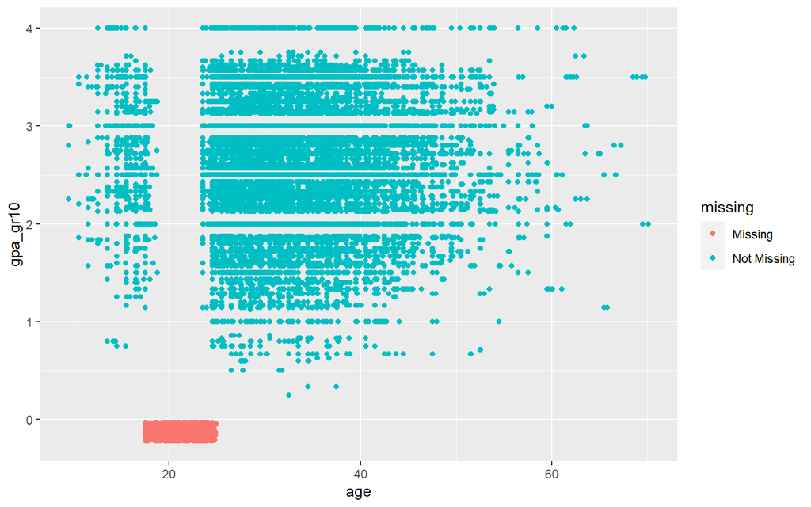

```r
constructed %>%
  ggplot(
   aes(
     x = age,
     y = gpa_gr10
   )
  ) +
 geom_miss_point()
```

## Calculate number of prior arrests and re-arrests

We want to calculate the number of arrests prior to each case. This will be done in two parts: all arrests prior to the study period will be calculated first and then arrests during the study period will be added.

All of the individual’s arrests prior to the study period are contained in prior_arrest.csv. If someone is not included in `prior_arrests.csv`, they had zero arrests at the start of the study period. Some people really do get arrested multiple times on the same day. We will count each arrest separately, regardless of whether another arrest occurred on the same day.

```r
prior_arrests <-
  prior_arrests %>%
  group_by(person_id) %>%
  summarise(
    preperiod_arrests = n()
  )
```

Some individuals were arrested multiple times during the study period and this should be accounted for in your prior arrest count.For example, if individual A was arrested 5 times prior to the study period and appears twice in the case file, their first arrest in the case file should have a prior arrest count of “5” and their second arrest should have a prior arrest count of “6”.

To calculate number of prior arrests in the study period, we will merge all the cases in the case data table to all other cases from the same individual. We will then count the number of cases that happened before the arrest date. All the arrests that happen after the case’s arrest date and before the case’s disposition date are considered re-arrests, which we also want to calculate.

```r
study_period_arrests <-
  # Keep only person ID and date of arrest
  cases %>%
  select(
    person_id,
    date = arrest_date
  ) %>%
  # Merge to all arrests from the same person
  full_join(
    cases %>%
      select(
        person_id,
        caseid,
        arrest_date,
        dispos_date
      ),
    by = "person_id"
  ) %>%
  # For each combination of cases, create a dummy indicating whether
  # it is a prior arrest or a re-arrest
  mutate(
    prior_arrest = date < arrest_date,
    re_arrest = date > arrest_date & date < dispos_date
  )
```

For each case, we will now calculate the number of re-arrests and prior arrests during the study period by adding all the occurrences identified earlier.

```r
study_period_arrests <-
  study_period_arrests %>%
  group_by(caseid, person_id) %>%
  summarise(
    period_arrests = sum(prior_arrest, na.rm = TRUE),
    re_arrest = max(re_arrest) %>% as.logical()
  )
```

This information needs to be combined with the information on the pre-study period arrests to calculate the total number of prior arrests.

```r
all_arrests <-
  study_period_arrests %>%
  # Combine both datasets
  left_join(
    prior_arrests,
    by = "person_id"
  ) %>%
  # Add pre-study and study period arrests
  rowwise() %>%
  mutate(
    prior_arrests = sum(
      period_arrests, preperiod_arrests,
      na.rm = TRUE
    )
  )
```

To check that this calculation matches the original data received from the SA Office, we will also combine it to the raw checks data

```r
constructed <-
  constructed %>%
  left_join(
    all_arrests,
    by = c("person_id", "caseid")
  )
```

We will then include two statements to check that the values match. If they don’t, the code will break.

```r
assert_that(
  all(
    constructed$prior_arrests.x == constructed$prior_arrests.y
  )
)
```

```
## [1] TRUE
```

```r
assert_that(
  all(
    constructed$re_arrest.x == constructed$re_arrest.y
  )
)
```

```
## [1] TRUE
```

## Final dataset organization

Factors are usually sorted in alphabetical order. This means the base category for race will be “Asian”. For comparison purposes, however, we want it to be “White”. The next few lines of code change the order of the factors.

```r
constructed <-
  constructed %>%
  mutate(
    race = fct_relevel(
      race,
      c("White", "Black", "Asian")
    )
  )
```

For our graphs and tables, we want treatment assignment values to be “treament” vs “control” instead of `TRUE` and `FALSE`, so we will rename the categories.

```r
constructed <-
  constructed %>%
  mutate(
    treat = case_when(
      treat == 1 ~ "Treatment",
      treat == 0 ~ "Control"
    )
  )
```

We will also remove from the dataset intermediate variables that we used to create indicators, but will not be used for analysis.

```r
constructed <-
  constructed %>%
  select(
    -c(
      st_address,
      city,
      bdate,
      contains("period"),
    ),
    -contains(".y"),
    prior_arrests = prior_arrests.x,
    re_arrest = re_arrest.x
  )
```

Finally, we will create variable labels to be shown in graphs and tables

```r
constructed <-
  constructed %>%
  var_labels(
    caseid = "Case ID",
    person_id = "Person ID",
    arrest_date = "Date of arrest",
    dispos_date = "Date of disposition",
    treat = "Treatment status",
    re_arrest = "Arrestee was rearrested",
    prior_arrests = "Number of arrestee's prior arrests",
    race = "Arrestee's race",
    gender = "Arrestee's gender",
    age = "Arrestee's age on arrest date"
  )
```

This is the data table to be saved.

```r
write_rds(
  constructed,
  here(
    "data",
    "final",
    "analysis-data.rds"
  )
)

skim(constructed)
```

**Variable type: character**

| skim_variable | n_missing | complete_rate | min | max | empty | n_unique | whitespace |
| --- | --- | --- | --- | --- | --- | --- | --- |
| treat | 0 | 1 | 7 | 9 | 0 | 2 | 0 |

**Variable type: Date**

| skim_variable | n_missing | complete_rate | min | max | median | n_unique |
| --- | --- | --- | --- | --- | --- | --- |
| arrest_date | 0 | 1 | 2012-01-02 | 2013-10-28 | 2012-12-01 | 666 |
| dispos_date | 0 | 1 | 2012-01-05 | 2018-03-04 | 2013-06-03 | 1486 |

**Variable type: factor**

| skim_variable | n_missing | complete_rate | ordered | n_unique | top_counts |
| --- | --- | --- | --- | --- | --- |
| race | 0 | 1 | FALSE | 3 | Bla: 18249, Whi: 5512, Asi: 1239 |
| gender | 0 | 1 | FALSE | 2 | Mal: 20064, Fem: 4936 |

**Variable type: logical**

| skim_variable | n_missing | complete_rate | mean | count |
| --- | --- | --- | --- | --- |
| re_arrest | 0 | 1 | 0.21 | FAL: 19747, TRU: 5253 |

**Variable type: numeric**

| skim_variable | n_missing | complete_rate | mean | sd | p0 | p25 | p50 | p75 | p100 | hist |
| --- | --- | --- | --- | --- | --- | --- | --- | --- | --- | --- |
| caseid | 0 | 1.00 | 49990.52 | 28831.03 | 4.00 | 24848.50 | 50052.00 | 74951.25 | 99998.00 | ▇▇▇▇▇ |
| person_id | 0 | 1.00 | 9966.40 | 5800.75 | 1.00 | 4884.00 | 9985.00 | 14975.00 | 20000.00 | ▇▇▇▇▇ |
| prior_arrests | 0 | 1.00 | 3.80 | 2.14 | 0.00 | 2.00 | 4.00 | 5.00 | 16.00 | ▇▆▂▁▁ |
| age | 0 | 1.00 | 30.34 | 7.80 | 9.51 | 24.51 | 29.51 | 35.51 | 70.12 | ▂▇▃▁▁ |
| gpa_gr10 | 4865 | 0.81 | 2.66 | 0.65 | 0.25 | 2.20 | 2.71 | 3.14 | 4.00 | ▁▂▆▇▃ |
| gpa_gr9 | 4865 | 0.81 | 2.66 | 0.65 | 0.00 | 2.25 | 2.71 | 3.14 | 4.00 | ▁▁▅▇▃ |

# Statistical Analysis

In this section, we will analyze the data to determine whether the program was success in reducing re-arrests. For the purpose if this analysis, we assume that the treatment was delivered at the case level, meaning the same individual could be arrested multiple times, but not join the program on all of their arrests.

## Demographics

Our study sample consists of 25000 cases. A total of 14353 individuals are present in the data. The information available is summarized in the table below.

```r
constructed %>%
  select(
    -caseid,
    -person_id,
    -treat
  ) %>%
  st()
```

Summary Statistics

| Variable | N | Mean | Std. Dev. | Min | Pctl. 25 | Pctl. 75 | Max |
| --- | --- | --- | --- | --- | --- | --- | --- |
| re_arrest | 25000 |  |  |  |  |  |  |
| … No | 19747 | 79% |  |  |  |  |  |
| … Yes | 5253 | 21% |  |  |  |  |  |
| prior_arrests | 25000 | 3.798 | 2.138 | 0 | 2 | 5 | 16 |
| race | 25000 |  |  |  |  |  |  |
| … White | 5512 | 22% |  |  |  |  |  |
| … Black | 18249 | 73% |  |  |  |  |  |
| … Asian | 1239 | 5% |  |  |  |  |  |
| gender | 25000 |  |  |  |  |  |  |
| … Female | 4936 | 19.7% |  |  |  |  |  |
| … Male | 20064 | 80.3% |  |  |  |  |  |
| age | 25000 | 30.344 | 7.802 | 9.507 | 24.51 | 35.507 | 70.115 |
| gpa_gr10 | 20135 | 2.656 | 0.646 | 0.25 | 2.2 | 3.143 | 4 |
| gpa_gr9 | 20135 | 2.662 | 0.652 | 0 | 2.25 | 3.143 | 4 |

Because we do not have grades constructed for all, the population, grades will not be taken into account for analysis. Note that the study population is made up mostly of black men, as illustrated in the graph below.

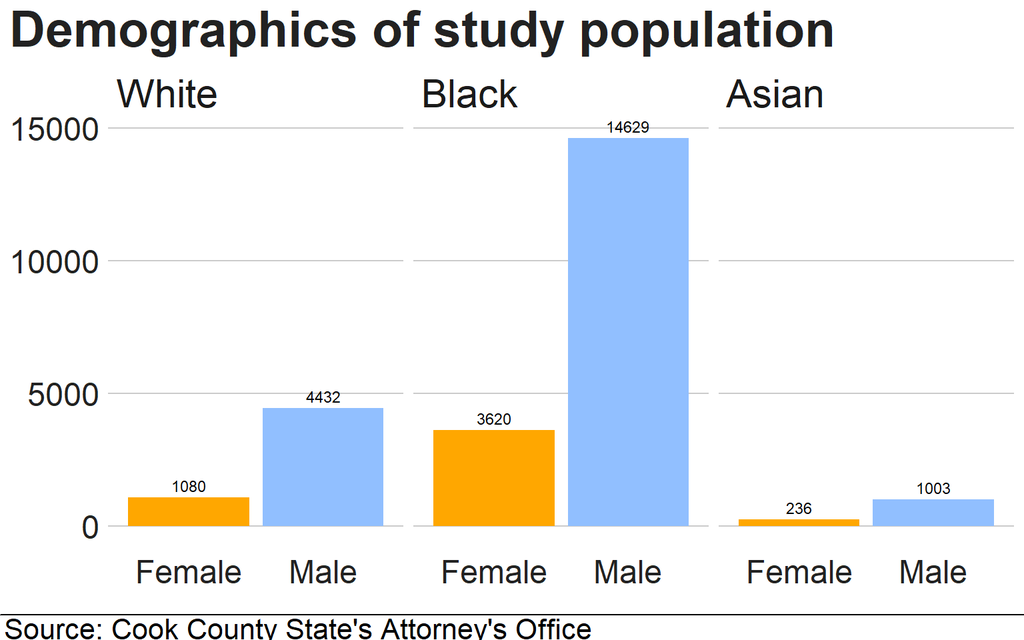

```r
plot <-
  constructed %>%
  group_by(gender, race) %>%
  summarize(count = n()) %>%
  ggplot(
    aes(
      x = gender,
      fill = gender,
      y = count,
      label = count
    )
  ) +
  geom_col() +
  geom_text(
    vjust = -.5,
    size = 3
  ) +
  facet_grid(cols = vars(race)) +
  scale_fill_manual(values = colors) +
  labs(title = "Demographics of study population") +
  bbc_style() +
  theme(legend.position = "none")

 finalise_plot(
    plot_name = plot,
    source = "Source: Cook County State's Attorney's Office",
    save_filepath = here(
      "output",
      "race_v_gender.png"
    ),
    width_pixels = 640,
    height_pixels = 550
  )
```

The balance table below shows the characteristics of defendants in the treatment and the control group.

```r
constructed %>%
  select(
    treat,
    prior_arrests,
    race,
    gender,
    age
  ) %>%
  sumtable(group = "treat", group.test = TRUE)
```

Summary Statistics

| treat Variable | Control N | Control Mean | Control SD | Treatment N | Treatment Mean | Treatment SD | Test |
| --- | --- | --- | --- | --- | --- | --- | --- |
| prior_arrests | 11851 | 3.152 | 1.849 | 13149 | 4.381 | 2.213 | F=2243.31*** |
| race | 11851 |  |  | 13149 |  |  | X2=1.629 |
| … White | 2651 | 22.4% |  | 2861 | 21.8% |  |  |
| … Black | 8624 | 72.8% |  | 9625 | 73.2% |  |  |
| … Asian | 576 | 4.9% |  | 663 | 5% |  |  |
| gender | 11851 |  |  | 13149 |  |  | X2=0.889 |
| … Female | 2370 | 20% |  | 2566 | 19.5% |  |  |
| … Male | 9481 | 80% |  | 10583 | 80.5% |  |  |
| age | 11851 | 28.732 | 7.169 | 13149 | 31.798 | 8.06 | F=1001.461*** |

Statistical significance markers: * p<0.1; ** p<0.05; *** p<0.01

While gender and race are balanced across treatment and control groups, this is not true for age and number of prior arrests. Treated arrestees are on average 3 years older than arrestees in the control group, as further illustrate in the figure below. Treated arrestees also have more prior arrests on average. For this reason we will include controls for these characteristics when estimating treatment effects.

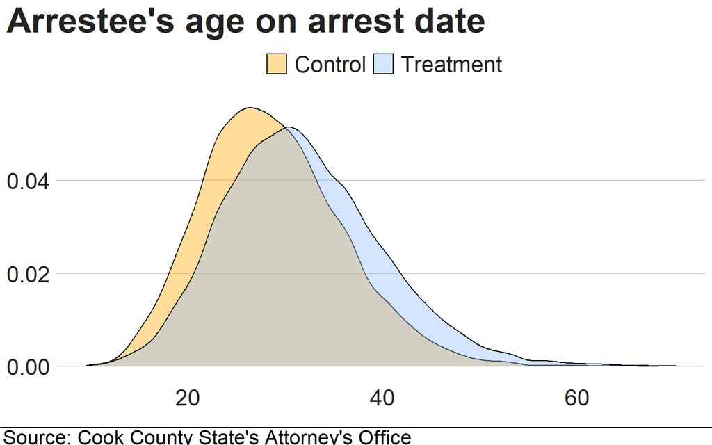

```r
plot <-
  ggplot(constructed) +
  aes(
    x = age,
    fill = treat
  ) +
  geom_density(alpha = .4) +
  labs(
    y = "Density",
    fill = get_label(constructed$treat),
    title = get_label(constructed$age)
  ) +
  scale_fill_manual(values = colors) +
  bbc_style()

  finalise_plot(
    plot_name = plot,
    source = "Source: Cook County State's Attorney's Office",
    save_filepath = here(
      "output",
      "age.png"
    ),
    width_pixels = 640,
    height_pixels = 550
  )
```

## Does the program reduce the likelihood of re-arrest before disposition?

To determine whether the program reduced the likelihood of re-arrest before disposition, we will run a regression of whether a re-arrest occurred on the treatment status. Given that defendant’s age and number of prior arrests were not balanced, we will also include them as control variables. Finally, since the same person can be present multiple times in the constructed, and the outcomes for a given individual are likely correlated, we will cluster standard errors at the level of the individual. The table below shows the results.

```r
reg_all <-
  felm(re_arrest ~ treat | 0 | 0 | person_id,
       constructed)

reg_all_control <-
  felm(re_arrest ~ treat + age + prior_arrests | 0 | 0 | person_id,
       constructed)


huxreg(
  reg_all, reg_all_control,
   coefs = c(
     "Treated" = "treatTreatment",
     "Age on arrest date" = "age",
     "Number of prior arrests" = "prior_arrests"
  ),
  stars = c(`*` = 0.1, `**` = 0.05, `***` = 0.01),
  statistics = c("N" = "nobs"),
  note = "{stars}. Standard errors clustered at person-level in parentheses. All specifications control for age and prior number of arrests."
)
```

|  | (1) | (2) |
| --- | --- | --- |
| Treated | 0.016 *** | -0.015 *** |
|  | (0.005) | (0.005) |
| Age on arrest date |  | 0.004 *** |
|  |  | (0.000) |
| Number of prior arrests |  | 0.016 *** |
|  |  | (0.001) |
| N | 25000 | 25000 |
| *** p < 0.01; ** p < 0.05; * p < 0.1. Standard errors clustered at person-level in parentheses. All specifications control for age and prior number of arrests. |  |  |

## Who is most likelly to benefit from the program?

The State’s Attorney’s Office is interested in expanding the program if it is shown to reduce re-arrest. However, they do not have the budget to serve every individual on bail awaiting trial. In order to make best use of their restricted budget, they would like to target the individuals most likely to benefit from the program. Using the data available to you, what recommendation would you make regarding who to serve?

The figure below shows the average treatment effect by demographics in standard deviations. It indicates that when considering different populations separately, black defendants show a reduced likelihood of re-arrest, while we cannot reject that white and asian defendants do not respond to the program.

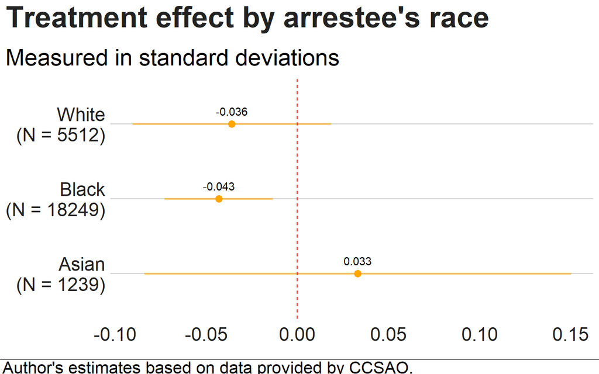

```r
source(here("code/functions.R"))
plot(constructed, "race", unique(constructed$race))
```

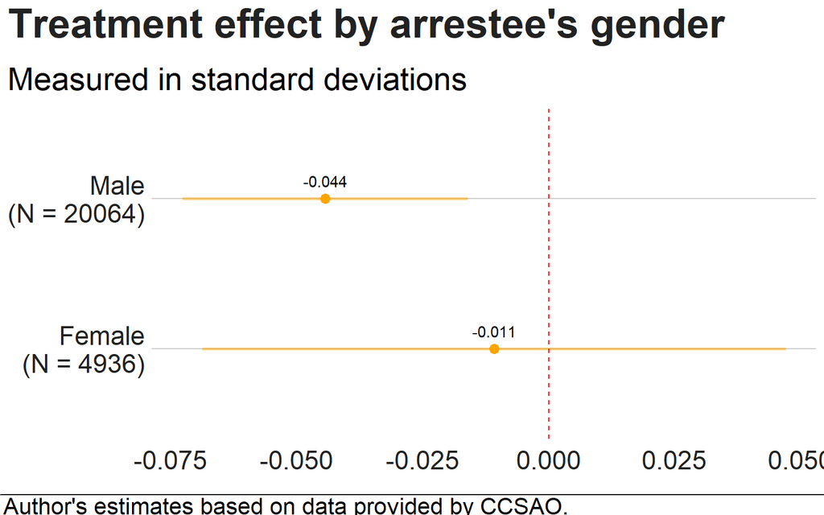

```r
plot(constructed, "gender", unique(constructed$gender))
```

```r
reg_gender <-
  felm(
    re_arrest ~ treat * gender + age + prior_arrests | 0 | 0 | person_id,
    constructed
  )

reg_race <-
  felm(
    re_arrest ~ treat * race + age + prior_arrests | 0 | 0 | person_id,
    constructed
  )

huxreg(
  reg_all_control, reg_gender, reg_race,
   coefs = c(
     "Treated" = "treatTreatment",
     "Treated x Male" = "treatTreatment:genderMale",
     "Treated x Black" = "treatTreatment:raceBlack",
     "Treated x Asian" = "treatTreatment:raceAsian"
  ),
   stars = c(`*` = 0.1, `**` = 0.05, `***` = 0.01),
   note = "{stars}. Standard errors clustered at person-level in parentheses. All specifications control for age and prior number of arrests."
)
```

|  | (1) | (2) | (3) |
| --- | --- | --- | --- |
| Treated | -0.015 *** | -0.002 | -0.014 |
|  | (0.005) | (0.012) | (0.011) |
| Treated x Male |  | -0.016 |  |
|  |  | (0.013) |  |
| Treated x Black |  |  | -0.004 |
|  |  |  | (0.012) |
| Treated x Asian |  |  | 0.018 |
|  |  |  | (0.026) |
| N | 25000 | 25000 | 25000 |
| R2 | 0.019 | 0.019 | 0.019 |
| *** p < 0.01; ** p < 0.05; * p < 0.1. Standard errors clustered at person-level in parentheses. All specifications control for age and prior number of arrests. |  |  |  |